# Project 3 - Transfer Learning

In this project I used the driving dataset provided by Udacity to train a model using a convolutional neural network. The only inputs to the model are the steering angles and camera images from the left, center, and right cameras mounted on the vehicle driving in a simulated environment.

The model is trained to predict the steering angle based on the vehicles location on the track and other features from the camera images.

```python
import pandas as pd
import numpy as np
import keras
import matplotlib.pyplot as plt
import csv
import cv2
from sklearn.model_selection import train_test_split
from sklearn.utils import shuffle
from keras.models import *
from keras.layers import *
from keras.optimizers import Adam
%matplotlib inline
```

```python
### folder filepath for log data and images ###
log_path = '/Users/srobinson/CarND-Term1-Starter-Kit/data/driving_log.csv'
data_filepath = '/Users/srobinson/CarND-Term1-Starter-Kit/data/'
columns = ['center', 'left', 'right', 'steering', 'throttle', 'brake', 'speed']
df = pd.read_csv(log_path, names = columns)

### variables for resized images used to train model ###
img_width = 16
img_height = 32

### batch size and epochs ###
batch_size=128
nb_epoch=10
```

```python
df.iloc[:2]
```

|  | center | left | right | steering | throttle | brake | speed |
| --- | --- | --- | --- | --- | --- | --- | --- |
| 0 | IMG/center_2016_12_01_13_30_48_287.jpg | IMG/left_2016_12_01_13_30_48_287.jpg | IMG/right_2016_12_01_13_30_48_287.jpg | 0.0 | 0.0 | 0.0 | 22.14829 |
| 1 | IMG/center_2016_12_01_13_30_48_404.jpg | IMG/left_2016_12_01_13_30_48_404.jpg | IMG/right_2016_12_01_13_30_48_404.jpg | 0.0 | 0.0 | 0.0 | 21.87963 |

## Data Exploration/Visualisation

I first visualized the images and steering data to get an idea of possible issues to address.

## Data Preprocessing and Creating Additional Data

I ended up only using the Udacity dataset because I found it difficult to record clean data that wouldn't make model train the car irratically.

The simulator records data into a csv log file which references left, center, and right images. The log file also records other telemetry data including steering, throttle, brake, and speed. However, I only used steering in this project.

My first preprocessing step was to resize the original images to a smaller footprint. This parameter seemed to have quite a large impact on the overall performance of model. I tried numerious sizes and the one that seemed to work the best was 16 Height by 32 Width.

I decided to convert the original RGB color images into HSV color space. I then chose to just use the 'S' or saturation portion because this seemed to easly differentiate between the road and the other obstacles. By doing this it also drastically reduced the size of the data that had to be processed which would make training much quicker. I also tried converting the original color images into grayscale images but this didn't workout as well as the HSV images.

I also decided to add more data to the Udacity dataset by flipping the images about the y-axis and reversing the steering angle direction. This would make sure that the model wouldn't be biased toward making more left turns.

Finally, I decided to also artificially modify the steering angles of the left and right camera images by increasing their angles. This was done in an attempt to bring the car back to the center of the track. I tried a few different values for this but I got the best results by adding/subtracting 0.4 degrees to each cooresponding turn.

```python
df['steering'].describe()
```

```
count    8036.000000
mean        0.004070
std         0.128840
min        -0.942695
25%         0.000000
50%         0.000000
75%         0.000000
max         1.000000
Name: steering, dtype: float64
```

## Steering Data Visualisation

The steering input data below shows that the original Udacity data is quite normally distributed. However, it is clearly evident that the dataset is biased with many more examples of '0' steering angle compared to any other angles. It should also be noted that the Udacity dataset seems to be slightly biased to make left turns compared to right turns.

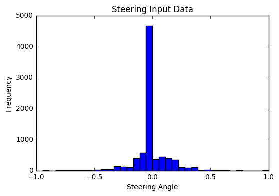

```python
df['steering'].plot.hist(bins=35)
plt.title('Steering Input Data')
plt.xlabel('Steering Angle')
```

```python
### import and read log files ###

logs = []
with open(log_path,'rt') as f:
    reader = csv.reader(f)
    for line in reader:
        logs.append(line)
log_labels = logs.pop(0)
```

## Resized HSV Images

The following images are examples of the resized (16 x 32) images and how they look in HSV color space compared to the original RGB images.

[figure not shown]

```python
### Preprocessing images ###
### Resized RGB images converted to HSV color space ###

img_l = plt.imread(data_filepath + (logs[20][1]).strip())
img_c = plt.imread(data_filepath + (logs[20][0]).strip())
img_r = plt.imread(data_filepath + (logs[20][2]).strip())
img_l_processed = (cv2.cvtColor(cv2.resize(img_l,(32,16)), cv2.COLOR_RGB2HSV))[:,:,1]
img_c_processed = (cv2.cvtColor(cv2.resize(img_c,(32,16)), cv2.COLOR_RGB2HSV))[:,:,1]
img_r_processed = (cv2.cvtColor(cv2.resize(img_r,(32,16)), cv2.COLOR_RGB2HSV))[:,:,1]

plt.subplot(3,2,1).axis('off')
plt.title('Left Camera Image')
plt.imshow(img_l)
plt.subplot(3,2,2).axis('off')
plt.title('Left HSV Processed Image')
plt.imshow( img_l_processed, cmap='gray')
plt.subplot(3,2,3).axis('off')
plt.title('Center Camera Image')
plt.imshow(img_c)
plt.subplot(3,2,4).axis('off')
plt.title('Center HSV Processed Image')
plt.imshow(img_c_processed,cmap='gray')
plt.subplot(3,2,5).axis('off')
plt.title('Right Camera Image')
plt.imshow(img_r)
plt.subplot(3,2,6).axis('off')
plt.subplots_adjust(hspace=.3)
plt.title('Right HSV Processed Image')
plt.imshow(img_r_processed,cmap='gray')
```

## Flipped images and steering angle

The following images are examples of flipped images that were created to augment the original dataset. Since the images were flipped about the y-axis the steering angles were also reversed (see images below). The steering angles for the left and right images were also adjusted by a constant of 0.4 (see images below) in an atttempt to center the car on the track.

This additional data was useful because it further normalized the data by providing more examples of both left and right turns.

```
Original Steering Angle: 0.0904655
```

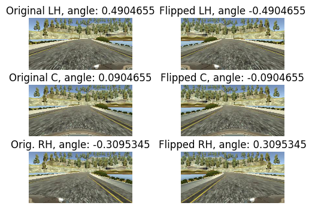

```python
img_l2 = plt.imread(data_filepath + (logs[200][1]).strip())
img_c2 = plt.imread(data_filepath + (logs[200][0]).strip())
img_r2 = plt.imread(data_filepath + (logs[200][2]).strip())

img_l_flip = img_l2.copy()
img_c_flip = img_c2.copy()
img_r_flip = img_r2.copy()

img_l_flip = cv2.flip(img_l_flip,1)
img_c_flip = cv2.flip(img_c_flip,1)
img_r_flip = cv2.flip(img_r_flip,1)
original_angle = str(df.steering[300])
left_angle = str((df.steering[300]+.4))
l_flip_angle = str(-(df.steering[300]+.4))
center_angle = str(df.steering[300])
c_flip_angle = str((-(df.steering[300])))
right_angle = str(((df.steering[300]-.4)))
r_flip_angle = str((-(df.steering[300]-.4)))

print('Original Steering Angle: '+ original_angle)
plt.subplot(3,2,1).axis('off')
plt.title('Original LH, angle: ' + left_angle)
plt.imshow(img_l2)
plt.subplot(3,2,2).axis('off')
plt.title('Flipped LH, angle '+ l_flip_angle )
plt.imshow(img_l_flip)
plt.subplot(3,2,3).axis('off')
plt.title('Original C, angle: '+ center_angle)
plt.imshow(img_c2)
plt.subplot(3,2,4).axis('off')
plt.title('Flipped C, angle: '+c_flip_angle)
plt.imshow(img_c_flip,)
plt.subplot(3,2,5).axis('off')
plt.title('Orig. RH, angle: ' + right_angle)
plt.imshow(img_r2)
plt.subplot(3,2,6).axis('off')
plt.subplots_adjust(hspace=0.3)
plt.title('Flipped RH, angle: '+ (r_flip_angle))
plt.imshow(img_r_flip)
```

## Development of Model Architecture

I first tried to train my model using Nvidia's and Commaai's CNNs. These models seemed like they should have provided good results since these models are already being used to drive by cloning the driving behavior of cars. I tried using each of these a few times but they both take a long time to train due to the large number of parameters in each. Instead I decided to start with a very low level network and build onto it if needed.

The input images were first preprocessed in order to cut down on the training time and also to reduce the degrees of freedom for the network to get lost in.

The model I ended up using is very basic in design and I am suprised that it worked as well as it did. The preprocessing, model creation, and model training was coded in python using keras (tensorflow) and is saved as model.py.

## Input

The input is 16x32x1 with 1 for S of HSV color channels.

## Output

Layer Fully Connected with 1 output value for the steering angle.

## Training the Model

I used the original data provided by Udacity and I increased the size of this dataset by flipping the original images/steering angle and adding them to the original dataset.

I tried to create additional data by using the simulator in training mode but I felt like the steering input were not very smooth and I thought this might adversely affect the training of the model.

I validated the training set by setting 10% of the total training data aside for validation.

The Adam Optimizer was used with a mean squared error loss. The batch size of 128 and 10 epochs were initialized at the beginning of model.py. The model trained on 43,389 randomized features and validated the results on 4,821 random sample images.

In order to pass the assigment the vehicle must drive around the first track staying on the road and not going up on or beyond the curb.

The trained model, (saved as model.json with weights saved as model.h5), is used in the simulator to test the results. The simulator outputs the center camera image, along with steering and throttle telemetry. The trained model takes those inputs and outputs new steering angle and throttle values. The throttle was hard coded to 0.2 and the input image was resized, the same as for training.

I tested the model on both track 1 and 2. The car swerved back and forth some of the time but they performed very well and did not go up on any curbs.